> Технический прогон 14.09.2026: все расчётные ячейки этого отчёта выполнены последовательно в чистом ядре на указанных в коде исходных результатах. FEM заново не решалась. Исполнение отчёта не повышает доказательный статус исходного исследования.

# 40.10. Пространственная сходимость расчёта чувствительности сборок TEPC-2–TEPC-7

**Численная проверка на индивидуальной КТ-геометрии Nix при 50 кГц.** Проверяется зависимость расчётных импедансов и показателей чувствительности от дискретизации объёмной конечноэлементной модели. Полученный результат относится к внутренней численной проверке модели. Он не является физической, экспериментальной или клинической валидацией.

**Результат математической проверки:** заданные критерии пространственной сходимости выполнены на выбранных состояниях.

## Аннотация

В предыдущем исследовании 40.09 шесть четырёхэлектродных сборок TEPC были сопоставлены по чувствительности к однородному одномоментному изменению удельного сопротивления всего компартмента мягких тканей, всей сердечной области и обоих лёгких. Настоящий этап отвечает на более узкий вопрос: сохраняются ли рассчитанные значения и различия между сборками при независимом перестроении тетраэдральной сетки?

Для проверки использованы три уровня дискретизации одной и той же наружной поверхности и одних и тех же тканевых масок. На каждом новом уровне сетка объёма построена заново, тетраэдры повторно отнесены к компартментам, а окрестности контактов приведены к одинаковому целевому шагу 1 мм. На каждом уровне рассчитаны одни и те же 40 заранее выбранных состояний удельного сопротивления для каждой из шести сборок. Выбор этих состояний был зафиксирован до получения новых результатов.

| Проверяемое условие | Результат |
| --- | --- |
| Все изменения $Z$, $S$, $B$, $Q$ на L09→L06 в допуске | да |
| Лидер неизменен на L12, L09 и L06 во всех проверках | да |
| Отрыв лидера превышает сеточную неопределённость во всех проверках | да |
| Разрешённые попарные предпочтения устойчивы | да |
| Объёмы L09→L06 в допуске | да |
| Общий вывод | критерий выполнен |

## 1. Что именно проверяется

Пространственная сходимость означает, что дальнейшее уменьшение характерного размера конечных элементов мало изменяет интересующий результат. В этой работе проверяются четыре группы величин:

1. $Z$ — передаточный импеданс сборки, Ом;
2. $S_k=\partial Z/\partial\rho_k$ — абсолютная производная по удельному сопротивлению целого компартмента $k$;
3. $B_k=|S_k|\,\Delta\rho_k$ — расчётный абсолютный отклик на полный литературный диапазон $\rho_k$;
4. $Q_k=B_k/\sum_j B_j$ — относительная избирательность, то есть доля отклика выбранного компартмента среди трёх изменяемых компартментов.

Абсолютная чувствительность отвечает на вопрос, насколько изменится измеряемый импеданс при заданном изменении параметра ткани. Относительная избирательность отвечает на другой вопрос: какая доля суммарного модельного отклика связана с этой тканью. Поэтому увеличение $Q_k$ возможно без заметного увеличения $B_k$: доля возрастает, если отклики других компартментов уменьшаются сильнее. Это не противоречие, а следствие различия знаменателя и числителя.

Проверка не оценивает локальные изменения внутри компартмента. Во всех состояниях удельное сопротивление каждого выбранного компартмента изменяется равномерно во всём его объёме. Сердечная маска рассматривается как единая эффективная область смеси крови и миокарда, поскольку отдельной маски крови в модели Nix нет.

## 2. Почему воксель КТ размером 1 мм не доказывает сходимость FEM

Размер вокселя характеризует дискретизацию исходного изображения. После КТ возникают другие численные представления: ручная сегментация, треугольные поверхности органов и тела, тетраэдральная сетка объёма, аппроксимация границ компартментов, дискретные контактные площадки и решение краевой задачи EIDORS. Ошибка каждого этапа имеет собственную природу.

Даже при вокселе 1 мм тетраэдр внутри туловища может быть существенно крупнее 1 мм. Граница органа в тетраэдральной модели может пересекать элементы иначе на двух независимо построенных сетках. Малый электрод диаметром 5 мм может включать разное число граничных граней. Поэтому одинаковая исходная КТ не гарантирует одинаковые $Z$, $S$, $B$, $Q$ или порядок сборок. Это проверяется только прямым сравнением решений на последовательно уточнённых сетках.

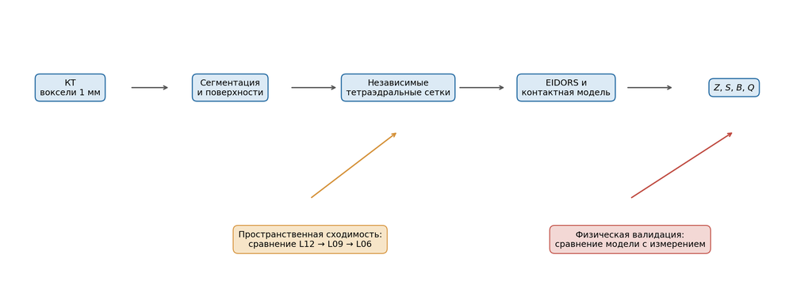

**Рисунок 1.** Размер вокселя задаёт исходную дискретизацию изображения. Пространственная сходимость и физическая валидация проверяют последующие, разные звенья доказательной цепочки.

## 3. Электродные сборки и неизменяемые условия

Топология и обозначения TEPC-2–TEPC-7 заимствованы из работы M. Metshein и соавторов *Study of Electrode Locations for Joint Acquisition of Impedance- and Electro-cardiography Signals* (EMBC, 2021) ([полный текст, рис. 3–4](https://www.paperhost.org/proceedings/embs/EMBC21/files/1232.pdf#page=3)). В расчёт переданы пользовательские JSON с центрами электродов на поверхности модели Nix. Эти координаты не являются метрическим восстановлением положений из рисунка статьи.

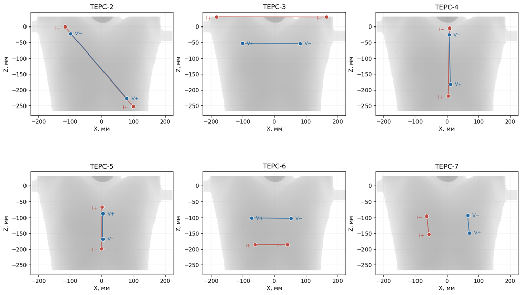

**Рисунок 2.** Проекции шести рассчитанных сборок на поверхность модели Nix. Цвет и подписи различают токовую пару I+/I− и измерительную пару V+/V−. Рисунок повторён из 40.09, чтобы численные обозначения в настоящем отчёте можно было связать с фактическим расположением электродов.

В расчёте сохранены координаты центров и роли четырёх электродов каждой сборки из 40.09. Все контакты являются круглыми поверхностными электродами диаметром 5 мм. Частота равна 50 кГц; контактная модель и удельный контактный импеданс одинаковы для всех сборок и уровней сетки. Наружная поверхность тела и исходные маски тканей также неизменны. Следовательно, наблюдаемое различие между уровнями относится к дискретизации объёма и повторной классификации тетраэдров, а не к намеренному изменению анатомии, электродов или электрофизических параметров.

## 4. План расчёта и заранее выбранные состояния $\rho$

Основная сетка L12 использует принятый ранее объёмный шаг туловища 12 мм, шаг области рук 1 мм и локальный шаг около контактов 1 мм. Для проверки независимо построены L09 и L06 с шагом туловища соответственно 9 и 6 мм. Шаг области рук и целевой шаг около контактов оставлены равными 1 мм. Такой план изменяет разрешение внутреннего объёма, сохраняя одинаковое разрешение контактов.

| Уровень | Шаг туловища, мм | Шаг рук, мм | Цель у контактов, мм | Узлы | Тетраэдры | Минимальный объём тетраэдра, мм³ |
| --- | --- | --- | --- | --- | --- | --- |
| L12 | 12 | 1 | 1 | 791 141 | 4 448 426 | 8,13e-07 |
| L09 | 9 | 1 | 1 | 900 000 | 5 000 000 | 1e-06 |
| L06 | 6 | 1 | 1 | 1 200 000 | 7 000 000 | 1e-06 |

Из полной физиологической области выбраны 40 состояний на сборку. В выбор вошли центр, восемь углов, шесть осевых крайних точек, состояния с наибольшими ошибками интерполяции и попарного сравнения, состояния с минимальными различиями между сборками, все ранее найденные обращения предпочтения и состояния, в которых каждая наблюдавшаяся сборка имела наибольший запас по $S$, $B$ или $Q$. Всего новый уровень требует $40\times6=240$ прямых решений EIDORS.

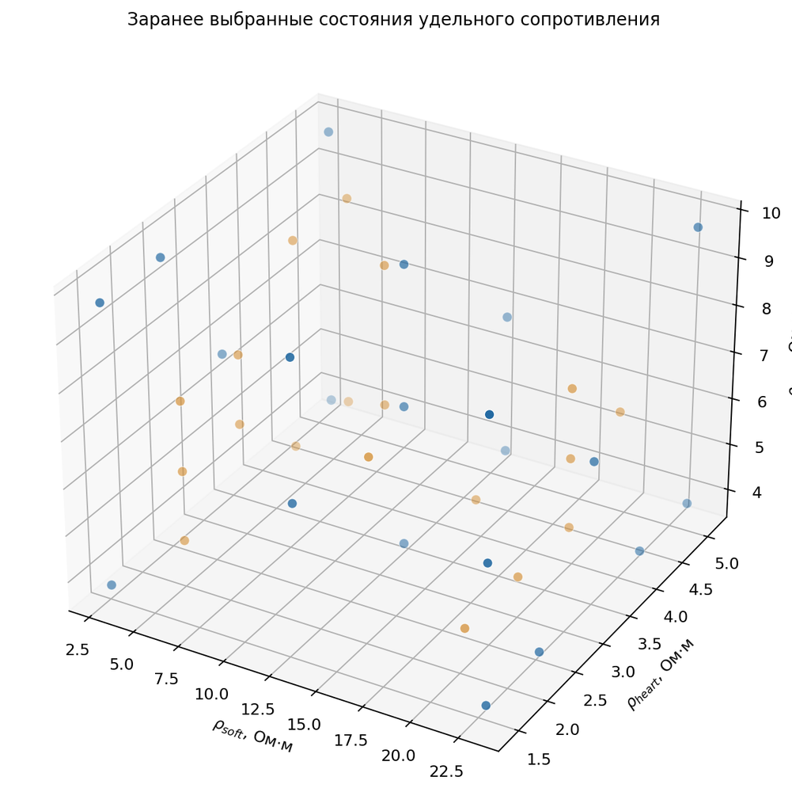

**Рисунок 3.** Синим показаны состояния основной сетки, оранжевым — дополнительные промежуточные и диагностические состояния. Цвет не кодирует величину чувствительности.

Фиксация состояний до нового расчёта устраняет подстройку проверки под уже увиденный результат. Однако это остаётся направленной выборкой из непрерывной области параметров, а не доказательством сходимости в каждой её точке.

## 5. Критерии достаточности

Для перехода между соседними уровнями вычисляется абсолютная разность одной и той же величины в одном состоянии и для одной сборки. Используются следующие рабочие допуски:

- для $Z$: 1% от большего по модулю значения плюс $10^{-8}$ Ом;
- для $S$ и $B$: 2% локального масштаба плюс 0,5% максимального значения соответствующей величины во всей сравниваемой матрице;
- для $Q$: абсолютная разность не более 0,01;
- для общего объёма тела: относительное различие не более 0,1%;
- для объёма отдельной группы тканей: относительное различие не более 2%.

Одной устойчивости чисел недостаточно для сравнения сборок. Поэтому дополнительно требуется, чтобы сборка с максимальным показателем не менялась между L12, L09 и L06. Различие лидера и второй сборки на L06 должно превышать сумму их изменений при переходе L09→L06. Для каждой пары сборок обращение порядка считается допустимым только тогда, когда различие на L06 не превышает оценённую сеточную неопределённость и пару нельзя численно различить.

Эти пороги являются заранее заданными инженерными критериями настоящей разработки. Они не являются метрологическими нормами прибора и не заменяют экспериментальную оценку погрешности.

## 6. Геометрическая сходимость сеток

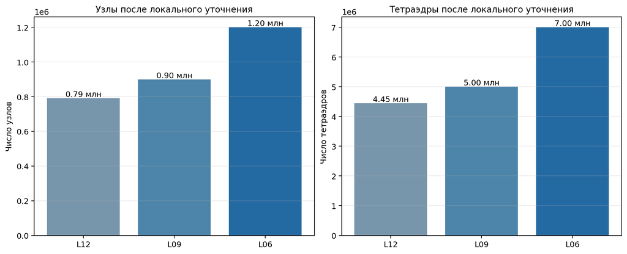

**Рисунок 4.** Фактический размер трёх FEM-сеток после одинакового локального уточнения около контактов. Уменьшение шага туловища должно увеличивать число степеней свободы; показаны реальные, а не номинальные размеры задачи.

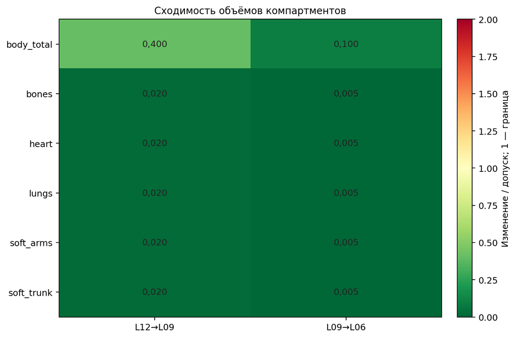

**Рисунок 5.** Относительное изменение объёма, делённое на установленный допуск. Для всего тела допуск равен 0,1%, для отдельных групп — 2%.

**Результат геометрической проверки:** на финальном переходе L09→L06 выполнено 6 из 6 объёмных критериев. Ни общий объём тела, ни объёмы отдельных групп не превысили заданный допуск.

Согласование объёмов необходимо, поскольку абсолютный вклад целого компартмента зависит и от поля чувствительности, и от объёма, которому присвоены его электрические свойства. При этом близкие объёмы не доказывают совпадения пространственного положения границ: две области одинакового объёма могут иметь различную форму. Поэтому объёмный тест рассматривается совместно с прямым сравнением решений.

## 7. Сходимость $Z$, $S$, $B$ и $Q$

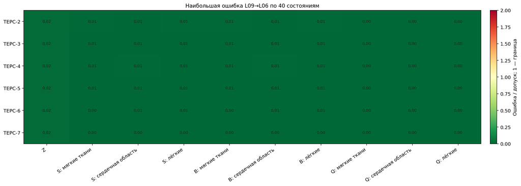

**Рисунок 6.** Для каждой сборки показано максимальное по выбранным состояниям отношение сеточного изменения к допуску. Значение меньше или равно 1 проходит критерий.

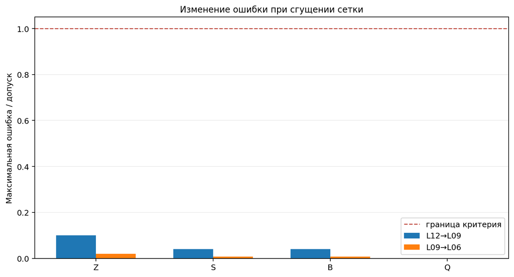

**Рисунок 7.** Максимальная нормированная ошибка для двух последовательных переходов. Уменьшение столбца на L09→L06 указывает на приближение к устойчивому решению; окончательное принятие определяется совокупностью критериев.

На финальном переходе L09→L06 прошли 2400 из 2400 проверок отдельных значений; превышений допуска: 0. Во всей двухпереходной матрице превышений: 0.

| Показатель | Переход | Сборка | Состояние | Компартмент | Ошибка/допуск | Относительное изменение |
| --- | --- | --- | --- | --- | --- | --- |
| Z | L12→L09 | TEPC-2 | rho_grid_n5_000124 | все | 0,100 | 0,0999% |
| S | L12→L09 | TEPC-2 | rho_grid_n5_000120 | лёгкие | 0,040 | 0,0999% |
| B | L12→L09 | TEPC-2 | rho_grid_n5_000120 | лёгкие | 0,040 | 0,0999% |
| Q | L12→L09 | TEPC-2 | rho_grid_n5_000020 | мягкие ткани | 0,000 | 2,292e-14% |

Цвет на рисунках показывает отношение изменения к допуску. Значение 1 соответствует границе принятия. Оно не показывает величину физиологической чувствительности: красная ячейка означает недостаточную численную устойчивость, а не высокую чувствительность ткани. Для оценки самой чувствительности используются таблицы и цветовые матрицы 40.09.

## 8. Устойчивость лидеров и попарных предпочтений

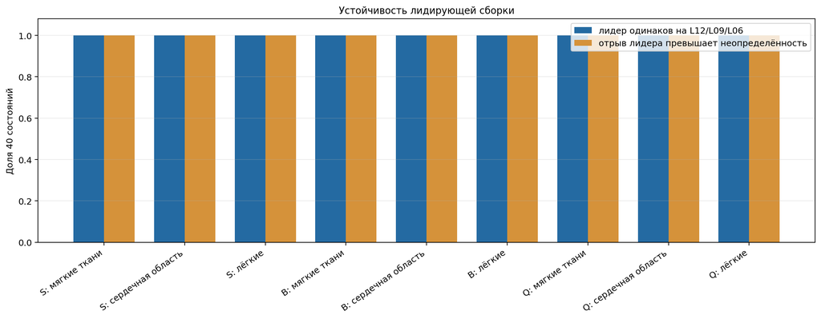

**Рисунок 8.** Синий столбец показывает долю состояний с неизменным лидером на трёх сетках. Оранжевый — долю состояний, где отрыв лидера на L06 больше оценённой неопределённости L09→L06.

| Показатель | Компартмент | Чаще всего лидер на L06 | Число состояний | Лидер стабилен | Отрыв разрешён |
| --- | --- | --- | --- | --- | --- |
| S | мягкие ткани | TEPC-2 | 40/40 | 100,0% | 100,0% |
| S | сердечная область | TEPC-4 | 40/40 | 100,0% | 100,0% |
| S | лёгкие | TEPC-2 | 39/40 | 100,0% | 100,0% |
| B | мягкие ткани | TEPC-2 | 40/40 | 100,0% | 100,0% |
| B | сердечная область | TEPC-4 | 40/40 | 100,0% | 100,0% |
| B | лёгкие | TEPC-2 | 39/40 | 100,0% | 100,0% |
| Q | мягкие ткани | TEPC-2 | 40/40 | 100,0% | 100,0% |
| Q | сердечная область | TEPC-7 | 31/40 | 100,0% | 100,0% |
| Q | лёгкие | TEPC-7 | 37/40 | 100,0% | 100,0% |

Число состояний, в которых сборка оказалась лидером, описывает только направленную контрольную выборку из 40 точек. Его нельзя трактовать как вероятность лидерства во всей физиологической области: состояния были выбраны для проверки границ, ошибок и малых разрывов, а не случайным образом.

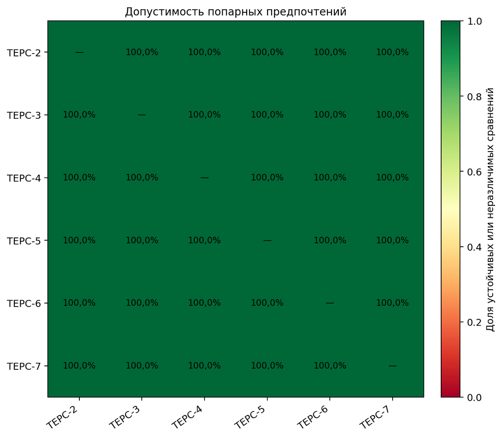

**Рисунок 9.** Для каждой пары приведена доля проверок по состояниям, показателям и компартментам, где порядок устойчив либо различие меньше сеточной неопределённости. Значение 100% требуется для принятия общего попарного критерия.

Неизменный лидер на трёх уровнях получен в 360 из 360 проверок показателя и компартмента в отдельном состоянии. Отрыв лидера превышает оценённую сеточную неопределённость в 360 из 360 случаев. Попарный критерий «устойчиво или численно неразличимо» выполнен в 5400 из 5400 сравнений; разрешённых обращений порядка: 0.

Если два варианта меняются местами при очень малом различии, это ещё не означает содержательного противоречия. Сначала проверяется, превышает ли их разность сеточную неопределённость. Если не превышает, корректный вывод состоит в том, что две сборки неразличимы с данным пространственным разрешением. Если превышает и знак различия меняется, сравнительное предпочтение считается неустойчивым.

## 9. Итоговая интерпретация и практическое решение

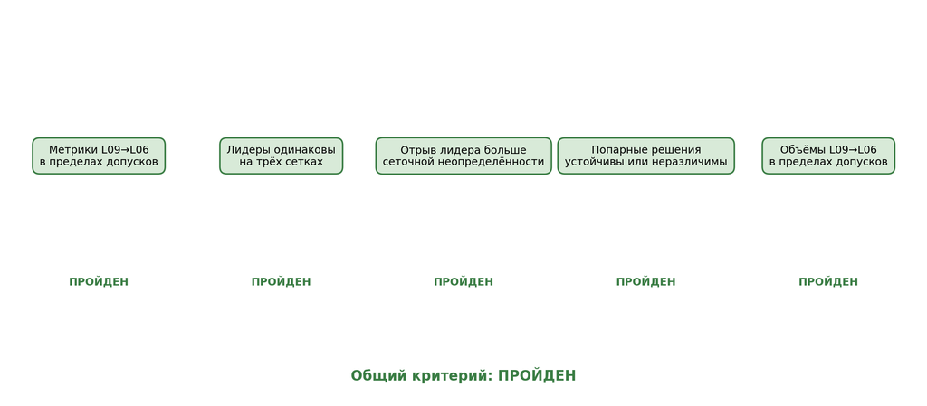

**Рисунок 10.** Итоговая матрица заранее заданных условий. Общий результат положителен только при одновременном выполнении всех пяти групп критериев.

**Практический вывод.** Для 40 заранее выбранных состояний переход от L09 к L06 изменяет импеданс и показатели чувствительности меньше установленных допусков; объёмы компартментов согласованы, лидеры сохраняются, а значимые попарные предпочтения не обращаются. Поэтому результат 40.09 можно считать численно устойчивым к исследованному сгущению объёмной сетки в данной модели Nix. Дополнительное сгущение не требуется для текущего сравнения этих шести сборок при контактах 5 мм.

Это решение не повышает результат до физически валидированного. Для новых электродных координат, другого диаметра контактов, другой анатомии или иной модели компартментов пространственную проверку следует повторить либо обосновать перенос через отдельный тест.

Проверка сходимости не выбирает целевую ткань и не устанавливает универсальную лучшую сборку. Она отвечает, можно ли доверять различиям, рассчитанным в 40.09, в пределах данной КТ-геометрии, контактной модели, физиологических диапазонов $\rho$ и проверенных состояний. Выбор сборки по мягким тканям, сердечной области или лёгким остаётся отдельным решением по абсолютному отклику, избирательности и ожидаемому отношению сигнал/шум.

## 10. Ограничения доказательности

1. **Результат математической модели.** Проверка относится к одной индивидуальной геометрии Nix и к тем маскам, которые использованы в расчёте.
2. **Рабочее допущение.** Внутри каждого компартмента $\rho$ изменяется равномерно и одномоментно. Пространственно неоднородные изменения не проверялись.
3. **Рабочее допущение.** Сердце представлено единой эффективной проводимостью смеси крови и миокарда.
4. **Ограничение выборки.** На новых сетках рассчитаны 40 заранее выбранных состояний на сборку, а не все точки непрерывной области $\rho$.
5. **Ограничение геометрии.** Наружная поверхность и тканевые маски фиксированы. Эта проверка не оценивает ошибку сегментации, положение органа, координаты электродов и радиус будущей эквивалентной сферы.
6. **Ограничение контактной модели.** Диаметр 5 мм и удельный контактный импеданс заданы моделью и пока не подтверждены измерением для реальных TEPC-контактов.
7. **Отсутствие физической валидации.** Сходимость между сетками показывает внутреннюю численную устойчивость, но не совпадение расчёта с реальным прибором, фантомом или человеком.
8. **Граница переноса.** Вывод нельзя автоматически переносить на другую анатомию, другой размер или форму электрода, другую частоту, иной монтаж или другую модель контакта.

## 11. Следующий этап: физическая валидация

После численной проверки требуются три последовательных эксперимента. P1 проверяет электрический тракт на известных нагрузках. P2 оценивает параметры контактной модели на фантоме и не используется для окончательной проверки. P3 применяет зафиксированные после P2 параметры к независимому набору фантомных измерений и сравнивает предсказанные $Z$, $\Delta Z$ и конечную чувствительность с измерением. Подробный протокол, поля таблиц, критерии разделения калибровки и проверки приведены в `MATLAB_TRKG4_real_subjects/docs/TEPC_PHYSICAL_VALIDATION_PROTOCOL.md`.

До получения P1–P3 формулировка результата должна оставаться следующей: методика прошла или не прошла указанную численную проверку на выбранных состояниях; физическая точность и экспериментальная применимость не установлены.

## 12. Воспроизводимость и происхождение

| Объект | SHA-256, начало | Статус |
| --- | --- | --- |
| Наружная поверхность и маски | 02cd6483a86baa9c… | фиксированы |
| Выбор состояний | d01eb497bec761b2… | 40 на сборку |
| Анализатор | c7ad92f16327643e… | проверен при сборке отчёта |
| Итоговый паспорт | 47bd9e186b6d1998… | passed_selected_state_independent_volume_mesh_convergence |

Файл `summary.json` и все шесть численных таблиц связаны контрольными суммами. Отчёт отказывается строиться, если изменён результат, выбор состояний, отчёт Gmsh или связанный с ним файл сетки. Исходные STL, MSH и MAT остаются локальными исследовательскими данными и в Git не включаются.

Для повторного запуска используется `MATLAB_TRKG4_real_subjects/tools/run_tepc_volume_convergence.ps1`; локальные пути к MATLAB, EIDORS, Python и исходной поверхности задаются аргументами. После расчёта этот отчёт строится `MATLAB_TRKG4_real_subjects/tools/build_tepc_volume_convergence_report.py`. Ноутбук содержит сохранённые результаты и встроенные рисунки; HTML экспортирован без исходного кода.

```
passed_selected_state_independent_volume_mesh_convergence
{'all_final_metric_changes_within_tolerance': True, 'all_selected_top_montages_stable_across_three_levels': True, 'all_fine_top_gaps_exceed_mesh_uncertainty': True, 'all_resolved_pair_preferences_stable': True, 'all_final_volume_changes_within_tolerance': True}
```